# Part 3: Exploring shifting spring transition dates

In this example, we will plot the relationship between average winter minimum temperatures and spring transition dates. The workflow is similar to the Daily forecasting, but we use annual metrics rather than daily, and join by year.

The steps in this workflow include:

1. download phenocam transition dates with `phenocamr` package
2. aggregate daily temperature to an annual metric
3. join annual temperature metric and spring transition dates
4. explore relationship between temperature and spring transition dates

## Example 1: SJER annual patterns

We will continue with the steps from part 1 - using GCC90 and weather data from the NEON SJER Site.

Deciding how to aggregate weather data into annual is an important step in the process. Daily values may not show a clear pattern - this is where we need to look for context in the literature.

The SJER site has an [oak woodland](https://phenocam.nau.edu/webcam/roi/NEON.D17.SJER.DP1.00033/EN_1000/). A study on oak species phenology found that winter precipitation and temperature were significant drivers of the timing of 5 oak species phenophases ([Armstrong-Herniman and Greenwood, 2021](https://bioone.org/journals/madro%c3%b1o/volume-68/issue-4/0024-9637-68.4.450/THE-ROLE-OF-WINTER-PRECIPITATION-AS-A-CLIMATIC-DRIVER-OF/10.3120/0024-9637-68.4.450.full)). To start let’s get average winter temperatures, which include the previous year December to the onset year February. To get the previous winter, we are first going to create a column for water year, which occurs from October to Sept, grouping winter over 1 year. Read more about water years [here](https://water.usgs.gov/nwc/explain_data.html).

```r
# read in csv from steps 1-2
neon_join = read.csv("gcc_neon_join.csv")
```

With the `neon_join` data frame, which contains daily values of GCC90 and temperature, we can aggregate to annual metric of winter temperature by filtering by month and grouping by water year.

```r
# winter_temps

# create new columns for water year and months
neon_join = neon_join %>%
  mutate(wy=calcWaterYear(datetime),
        month=month(datetime))

# summarize by winter
winter_t_df = neon_join %>%
  filter(variable=="gcc_90",
        month==12 | month<=2) %>%
  group_by(wy) %>%
  summarize(winter_T = mean(wssTempTripleMean, na.rm=T))

head(winter_t_df)
```

```
## # A tibble: 6 × 2
##      wy winter_T
##   <dbl>    <dbl>
## 1  2016   NaN
## 2  2017   NaN
## 3  2018   NaN
## 4  2019     9.61
## 5  2020    10.9
## 6  2021    10.5
```

Aggregating to annual values, while accounting for NAs, leaves us with only 3 years for data points, not enough to make an interesting plot, or predictions. This is specific to the SJER site, but keep in mind when working on your location.

The next step is to calculate the phenophase transition dates, using the estimation method shown in the Phenocam access guide on page 6.

The R package `phenocamr` includes functions to simplify this process, and is loaded below. Read more about the phenocamr package [here](https://bluegreen-labs.github.io/phenocamr/).

```r
install.packages('phenocamr')
library(phenocamr)
```

Moving forward, we will be using a different site, the [Smithsonian Conservation Biology Institute (SCBI)](https://www.neonscience.org/field-sites/scbi), which is a terrestrial field site in the foothills of the Blue Ridge Mountains in Front Royal, Virginia.

## Example 2: SCBI Site

SCBI is a temperate and humid site, with deciduous hardwood forests. The dominant species include the tulip tree (*Liriodendron tulipifera*) and Black walnut (*Juglans nigra*).

The next section uses data from the Phenocam network. [See a map of phenocam sites here](https://phenocam.nau.edu/webcam/network/map/). This network contains NEON sites, but is more expansive and contains other sites as well. We will keep the focus on NEON sites here to continue working with NEON weather summary data.

```r
# set your site - name is slightly different in phenocamr package
my_site = "NEON.D02.SCBI.DP1.00033"
```

We use the function `download_phenocam()`, with the site name as input, and this should download two files to your folder, in phenocam format. The files should end in:

1. “_DB_1000_3day.csv”
2. “_DB_1000_3rday_transition_dates.csv”

```r
# download phenocam - this should create 2 csv files
phenocamr::download_phenocam(
  veg_type = "DB", #DB for decid broadleaf, EN for evergreen, default is ALL
  roi_id = 1000,
  site = my_site,
  phenophase = TRUE,
  out_dir = "." # saves in current working dir
)
```

Use `read_phenocam()` to bring in the data structure to R, then select the `$data` object.

```r
# read in the phenocamr transition dates
pheno_td = read_phenocam(paste(my_site,"DB_1000_3day_transition_dates.csv", sep="_"))$data

str(pheno_td)
```

```
## 'data.frame':    68 obs. of  19 variables:
##  $ site                  : chr  "NEON.D02.SCBI.DP1.00033" "NEON.D02.SCBI.DP1.00033" "NEON.D02.SCBI.DP1.00033" "NEON.D02.SCBI.DP1.00033" ...
##  $ veg_type              : chr  "DB" "DB" "DB" "DB" ...
##  $ roi_id                : int  1000 1000 1000 1000 1000 1000 1000 1000 1000 1000 ...
##  $ direction             : chr  "rising" "rising" "rising" "rising" ...
##  $ gcc_value             : chr  "gcc_90" "gcc_90" "gcc_90" "gcc_90" ...
##  $ transition_10         : chr  "2017-04-05" "2018-04-13" "2019-04-06" "2020-03-24" ...
##  $ transition_25         : chr  "2017-04-08" "2018-04-21" "2019-04-10" "2020-03-31" ...
##  $ transition_50         : chr  "2017-04-13" "2018-04-29" "2019-04-16" "2020-04-08" ...
##  $ transition_10_lower_ci: chr  "2017-04-03" "2018-04-11" "2019-04-04" "2020-03-20" ...
##  $ transition_25_lower_ci: chr  "2017-04-07" "2018-04-19" "2019-04-09" "2020-03-30" ...
##  $ transition_50_lower_ci: chr  "2017-04-12" "2018-04-27" "2019-04-14" "2020-04-06" ...
##  $ transition_10_upper_ci: chr  "2017-04-07" "2018-04-16" "2019-04-08" "2020-03-27" ...
##  $ transition_25_upper_ci: chr  "2017-04-10" "2018-04-23" "2019-04-11" "2020-04-02" ...
##  $ transition_50_upper_ci: chr  "2017-04-14" "2018-04-30" "2019-04-17" "2020-04-09" ...
##  $ threshold_10          : num  0.338 0.337 0.34 0.339 0.34 ...
##  $ threshold_25          : num  0.352 0.355 0.357 0.353 0.352 ...
##  $ threshold_50          : num  0.385 0.391 0.39 0.383 0.388 ...
##  $ min_gcc               : num  0.327 0.326 0.329 0.328 0.33 ...
##  $ max_gcc               : num  0.441 0.445 0.44 0.435 0.436 ...
```

The data frame should include site, veg_type, roi_id, gcc_value, transition dates, and values of GCC at the transition. [Find the full metadata here.](https://phenocam.nau.edu/webcam/tools/summary_file_format/). In our case, we are interested in a `gcc_value` of `gcc_90` and the spring transition, or a `direction` of `rising`. We will use the `filter()` function below to specify this.

### Visualize transition dates

Next, following the steps from this [phenocam vignette](https://bluegreen-labs.github.io/phenocamr/articles/phenocamr-vignette.html), we can plot the smoothed GCC90 values with spring and fall 50% transition dates.

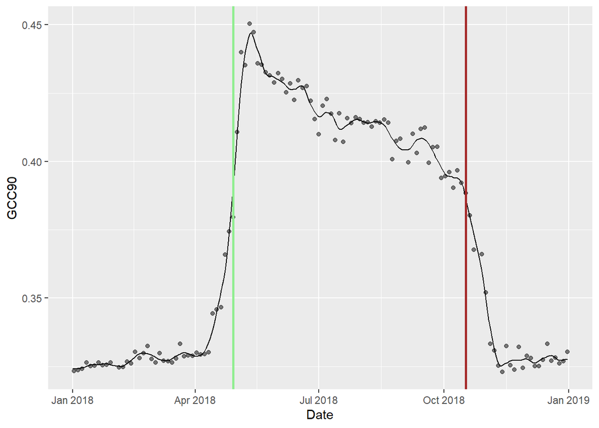

```r
# read phenocam object in
neon_site = read_phenocam(paste(my_site,"DB_1000_3day.csv", sep="_"))

df <- expand_phenocam(neon_site) # expand every 3 day to every day

df <- detect_outliers(df) # detect outliers

df <- smooth_ts(df) # smooth data using AIC

# fist convert data frame to plot
as.data.frame(df$data) %>%
  filter(year==2018) %>%
  # create a date column with date type
  mutate(date = as.Date(date)) %>%
  # plot
  ggplot() +
  geom_line(aes(x=date, y=smooth_gcc_90)) +
  geom_point(aes(x=date, y=gcc_90), alpha=0.5) +
  labs(x="Date", y="GCC90") +
  # rising "spring" greenup dates
  geom_vline(data=pheno_td[pheno_td$direction=="rising" & pheno_td$gcc_value=="gcc_90",],
             aes(xintercept=as_date(transition_50)), col="lightgreen", size=1) +
  # falling 'autumn' senescence dates
  geom_vline(data=pheno_td[pheno_td$direction=="falling" & pheno_td$gcc_value=="gcc_90",],
             aes(xintercept=as_date(transition_50)), col="brown", size=1)
```

To see the full time series, you can comment out the line that has `filter(year==2018)`.

### Download SCBI summary weather data

Here we are repeating the step for downloading weather summary as in part 1, using the `loadByProduct()` function and the ID for [summary weather statistics](https://data.neonscience.org/data-products/DP4.00001.001).

Once you run the below code chunk once, you will have an large list stored in R. Make sure to run the following code chunk to save the dataframe from the list as a CSV file on your local drive. This will make it easier to come back to.

```r
# set data ID
data_id = "DP4.00001.001"


# download the summary weather statistics files - for site SJER - check your console, this may take a minute

summary_weather <- loadByProduct(dpID=c(data_id),
                          site=c("SCBI"),
                          check.size=F,
                          progress=F
                          )
```

```r
daily_temp <- summary_weather$wss_daily_temp

write.csv(daily_temp, paste(my_site, "summary_weather_daily_temp.csv", sep="_"))
```

## Getting annual values

In order to do this, we need both the Spring green up transition dates and the weather summary to be annual values, in other words each row is a single year.

### Annual spring transition dates for GCC90

In the code below, we first filter by `direction=="rising"` to get only spring transition dates, as well as the `gcc_90` value. We then use `lubridate` functions to get the year (`year()`) and day of year (`yday()`) when the spring transitions happen.

This gives each transition date a value between 1-365 for each year.

```r
scbi_gcc = pheno_td %>% filter(direction=="rising",
                               gcc_value=="gcc_90") %>%
  mutate(year = year(transition_10),
         t10_doy = yday(transition_10),
         t25_doy = yday(transition_25),
         t50_doy = yday(transition_50)) %>%
  select(year, t10_doy, t25_doy, t50_doy, threshold_10, threshold_25, threshold_50)


head(scbi_gcc)
```

```
##   year t10_doy t25_doy t50_doy threshold_10 threshold_25 threshold_50
## 1 2017      95      98     103      0.33818      0.35214      0.38516
## 2 2018     103     111     119      0.33682      0.35516      0.39081
## 3 2019      96     100     106      0.34001      0.35706      0.38969
## 4 2020      84      91      99      0.33901      0.35307      0.38329
## 5 2021      89      94     101      0.33966      0.35207      0.38752
## 6 2022      97     101     108      0.33828      0.35194      0.38516
```

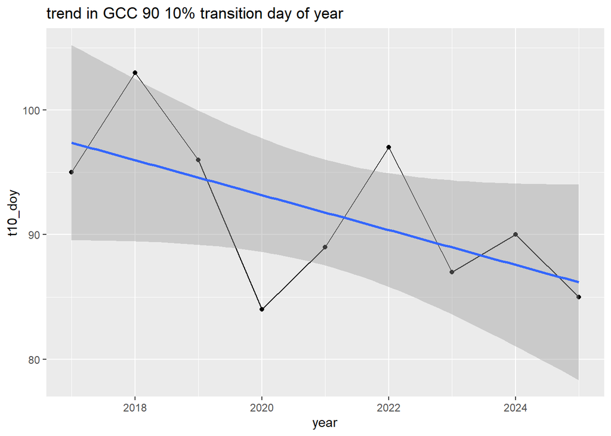

```r
ggplot(scbi_gcc, aes(x=year, y=t10_doy)) +
  geom_point() +
  geom_line() +
  geom_smooth(method='lm') +
  ggtitle("trend in GCC 90 10% transition day of year")
```

With the `scbi_gcc` data frame, we can create time series to see if the transition dates are happening earlier or later in the year.

### Average winter minimum temperature

In this code chunk we take these steps for the `w_temps` dataframe:

- use `lubridate` functions to create a year and month column
- use `calcWaterYear` to create a water year (`wy`) column
- use `group_by(wy)` to summarize variables by water year (wy)
- get the mean of `wssTempTripleMinimum` and save as new var `winter_tmin`

```r
daily_temp <- read.csv(paste(my_site, "summary_weather_daily_temp.csv", sep="_"))

w_temps = daily_temp %>%
  mutate(year = year(date),
         wy = calcWaterYear(date),
         month=month(date)) %>%
  filter(month==12 | month<3) %>%
  group_by(wy) %>%
  summarize(winter_tmin = mean(wssTempTripleMinimum, na.rm=T)) %>% rename(year=wy)


head(w_temps)
```

```
## # A tibble: 6 × 2
##    year winter_tmin
##   <dbl>       <dbl>
## 1  2015      -4.54
## 2  2016      -2.20
## 3  2017       0.370
## 4  2018      -0.946
## 5  2019      -1.04
## 6  2020       0.797
```

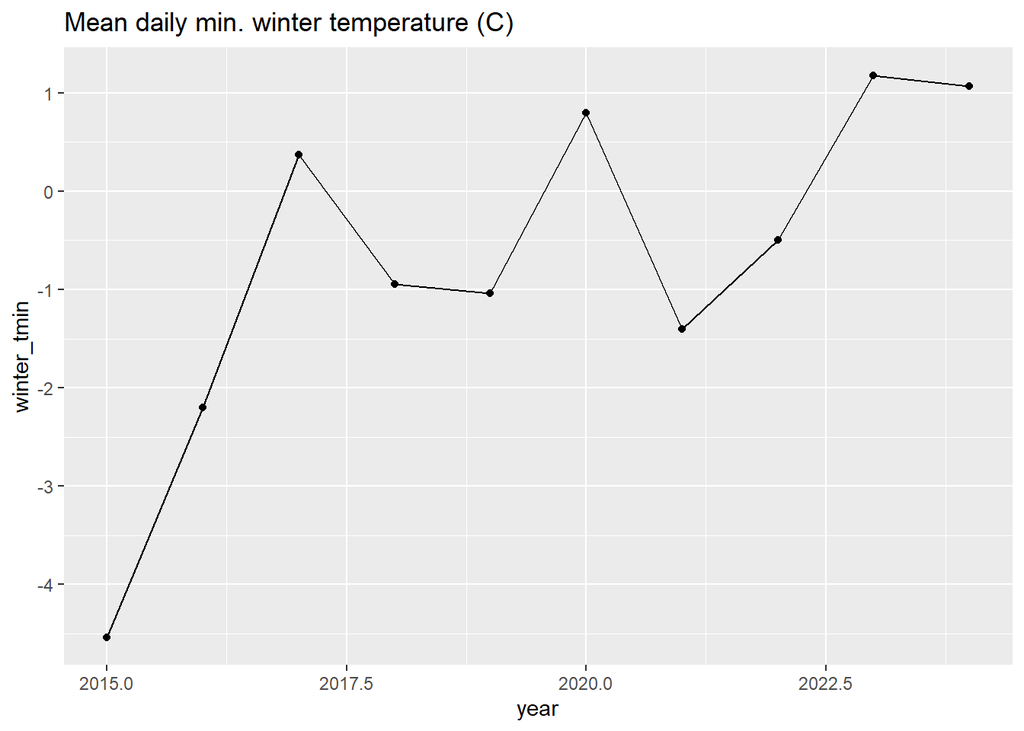

```r
ggplot(w_temps, aes(x=year, y=winter_tmin)) + geom_point() + geom_line() +
  ggtitle("Mean daily min. winter temperature (C)")
```

Average winter minimum temperatures increasing in this time period, which suggests there might be a correlation with the decreasing transition dates.

### Join the temperature and transition dates

Because both dataframes contain a `year` column, we can join them by year. With the full dataframe, we can create scatter plots to explore the relationship between average winter minimum temperature and spring transition dates. The `inner_join()` function combines columns, matching by year, and keeps all rows that do not contain NA. This leaves us with fewer years to work with, because the range for `scbi_gcc` is 2017-2025, while the range for `w_temps` is 2015-2024. Only the years present in both dataframes will be used.

If we wanted to include more variables to use in predicting transition dates, we would need to aggregate to annual values like the steps taken in the previous code chunk.

```r
# join data frames, will auto detect the year column in both as overlap
join_df = inner_join(w_temps, scbi_gcc)
```

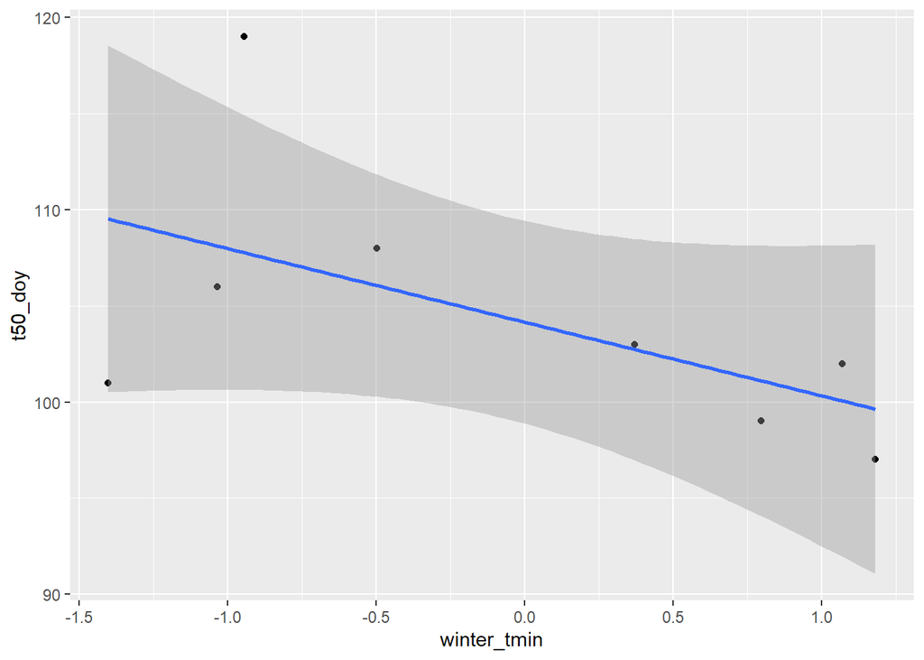

```r
# plot temp as driver and day of year as predictor
join_df %>%
  ggplot(aes(x=winter_tmin, y=t50_doy)) +
    geom_point() +
    geom_smooth(method="lm")
```

This plot shows a potential relationship between average winter minimum temperature and day of the year for GCC 90 50% transition.

# Part 3 Recap: